# Bellabeat case study

Ahmed,Younes

2022-06-13

#### Bellabeat company :

- Source of data :  
  (https://www.kaggle.com/datasets/arashnic/fitbit)

Bellabeat, a high-tech manufacturer of health-focused products for women. Bellabeat is a successful small company, but they have the potential to become a larger player in the global smart device market. Urška Sršen, cofounder and Chief Creative Officer of Bellabeat, believes that analyzing smart device fitness data could help unlock new growth opportunities for the company.

##### Ask for analysis

- What are some trends in smart device usage?
- How could these trends apply to Bellabeat customers?
- How could these trends help influence Bellabeat marketing strategy?

##### Task

Identify potential opportunities for growth and recommendations for the Bellabeat marketing strategy improvement based on trends in smart device usage.

##### loading packages

```r
install.packages("tidyverse")
```

[output not shown]

```r
library(tidyverse)
library(dplyr)
library(skimr)
library(here)
library(lubridate)
library(janitor)
library(ggplot2)
```

#### Import the data

```r
activity <- read.csv("dailyActivity_merged.xlsx.csv", header = TRUE, sep = ",")
dailyCalory <- read.csv("dailyCalories_merged.xlsx.csv",header = TRUE, sep = ",")
dailyIntensities <- read.csv("dailyIntensities_merged.xlsx.csv",header = TRUE, sep = ",")
dailySteps <- read.csv("dailySteps_merged.xlsx.csv", header = TRUE, sep = ",")
heartrate <- read.csv("heartrate_seconds_merged.xlsx.csv", header = TRUE, sep = ",")
sleepDay <- read.csv("sleepDay_merged.xlsx.csv", header = TRUE, sep = ",")
```

#### Explore the data

```r
n_distinct(activity$Id)
```

```
[1] 33
```

```r
n_distinct(dailyCalory$Id)
```

```
[1] 33
```

```r
n_distinct(dailySteps$Id)
```

```
[1] 33
```

```r
n_distinct(heartrate$Id)
```

```
[1] 7
```

```r
n_distinct(sleepDay$Id)
```

```
[1] 24
```

```r
n_distinct(dailyIntensities$Id)
```

```
[1] 33
```

#### more exploring

```r
activity %>%
  summary()
```

```
       Id            ActivityDate         TotalSteps       Calories    TotalDistance
 Min.   :1.504e+09   Length:940         Min.   :    0   Min.   :   0   Min.   : 0.00
 1st Qu.:2.320e+09   Class :character   1st Qu.: 3790   1st Qu.:1828   1st Qu.: 2.60
 Median :4.445e+09   Mode  :character   Median : 7406   Median :2134   Median : 5.25
 Mean   :4.855e+09                      Mean   : 7638   Mean   :2304   Mean   : 5.49
 3rd Qu.:6.962e+09                      3rd Qu.:10727   3rd Qu.:2793   3rd Qu.: 7.70
 Max.   :8.878e+09                      Max.   :36019   Max.   :4900   Max.   :28.00
 TrackerDistance  LoggedActivitiesDistance VeryActiveDistance ModeratelyActiveDistance
 Min.   : 0.000   Min.   :0.0000           Min.   : 0.000     Min.   :0.0000
 1st Qu.: 2.620   1st Qu.:0.0000           1st Qu.: 0.000     1st Qu.:0.0000
 Median : 5.245   Median :0.0000           Median : 0.210     Median :0.2400
 Mean   : 5.475   Mean   :0.1082           Mean   : 1.503     Mean   :0.5675
 3rd Qu.: 7.710   3rd Qu.:0.0000           3rd Qu.: 2.053     3rd Qu.:0.8000
 Max.   :28.030   Max.   :4.9421           Max.   :21.920     Max.   :6.4800
 LightActiveDistance SedentaryActiveDistance VeryActiveMinutes FairlyActiveMinutes
 Min.   : 0.000      Min.   :0.000000        Min.   :  0.00    Min.   :  0.00
 1st Qu.: 1.945      1st Qu.:0.000000        1st Qu.:  0.00    1st Qu.:  0.00
 Median : 3.365      Median :0.000000        Median :  4.00    Median :  6.00
 Mean   : 3.341      Mean   :0.001606        Mean   : 21.16    Mean   : 13.56
 3rd Qu.: 4.782      3rd Qu.:0.000000        3rd Qu.: 32.00    3rd Qu.: 19.00
 Max.   :10.710      Max.   :0.110000        Max.   :210.00    Max.   :143.00
 LightlyActiveMinutes SedentaryMinutes
 Min.   :  0.0        Min.   :   0.0
 1st Qu.:127.0        1st Qu.: 729.8
 Median :199.0        Median :1057.5
 Mean   :192.8        Mean   : 991.2
 3rd Qu.:264.0        3rd Qu.:1229.5
 Max.   :518.0        Max.   :1440.0
```

#### shorted activity (wanted to explore the 4 variables )

```r
Activity_1 <- activity %>%
  select(Id, TotalSteps, TotalDistance, Calories)
```

#### more about activity

```r
 Activity_1 %>%
    summary()
```

```
       Id              TotalSteps    TotalDistance      Calories
 Min.   :1.504e+09   Min.   :    0   Min.   : 0.00   Min.   :   0
 1st Qu.:2.320e+09   1st Qu.: 3790   1st Qu.: 2.60   1st Qu.:1828
 Median :4.445e+09   Median : 7406   Median : 5.25   Median :2134
 Mean   :4.855e+09   Mean   : 7638   Mean   : 5.49   Mean   :2304
 3rd Qu.:6.962e+09   3rd Qu.:10727   3rd Qu.: 7.70   3rd Qu.:2793
 Max.   :8.878e+09   Max.   :36019   Max.   :28.00   Max.   :4900
```

#### Looking if there is any relationship :

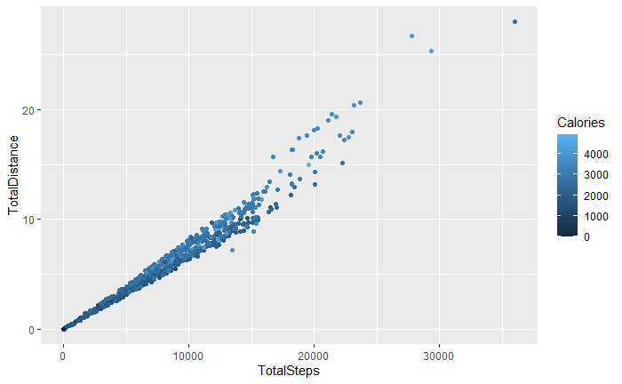

```r
  ggplot(data = Activity_1)+
    geom_point(mapping = aes(x= TotalSteps,y= TotalDistance, color=Calories))
```

```r
NA
NA
```

#### Sleep day

```r
sleepDay %>%
  summary()
```

```
       Id              SleepDay         TotalSleepRecords TotalMinutesAsleep TotalTimeInBed
 Min.   :1.504e+09   Length:413         Min.   :1.000     Min.   : 58.0      Min.   : 61.0
 1st Qu.:3.977e+09   Class :character   1st Qu.:1.000     1st Qu.:361.0      1st Qu.:403.0
 Median :4.703e+09   Mode  :character   Median :1.000     Median :433.0      Median :463.0
 Mean   :5.001e+09                      Mean   :1.119     Mean   :419.5      Mean   :458.6
 3rd Qu.:6.962e+09                      3rd Qu.:1.000     3rd Qu.:490.0      3rd Qu.:526.0
 Max.   :8.792e+09                      Max.   :3.000     Max.   :796.0      Max.   :961.0
 loss_.time_beforeSleeping
 Min.   :  0.00
 1st Qu.: 17.00
 Median : 25.00
 Mean   : 39.17
 3rd Qu.: 40.00
 Max.   :371.00
```

#### want to know how long time spending on bed before sleeping, so I added a new column by make subtraction

```r
sleepDay["time_onBed_before_sleeping"]<-sleepDay$TotalTimeInBed - sleepDay$TotalMinutesAsleep
```

#### Spot on time on bed before sleeping :

```r
Stats_time_on_bed_before_sleeping <- sleepDay %>%
 summarise(min(time_onBed_before_sleeping),
             mean(time_onBed_before_sleeping),
             max(time_onBed_before_sleeping))
```

#### r Sleep Day summary

```r
 sleepDay %>%
   select(TotalMinutesAsleep,
          TotalTimeInBed,
          time_onBed_before_sleeping) %>%
   summary()
```

```
 TotalMinutesAsleep TotalTimeInBed  time_onBed_before_sleeping
 Min.   : 58.0      Min.   : 61.0   Min.   :  0.00
 1st Qu.:361.0      1st Qu.:403.0   1st Qu.: 17.00
 Median :433.0      Median :463.0   Median : 25.00
 Mean   :419.5      Mean   :458.6   Mean   : 39.17
 3rd Qu.:490.0      3rd Qu.:526.0   3rd Qu.: 40.00
 Max.   :796.0      Max.   :961.0   Max.   :371.00
```

#### Plot Sleep Day

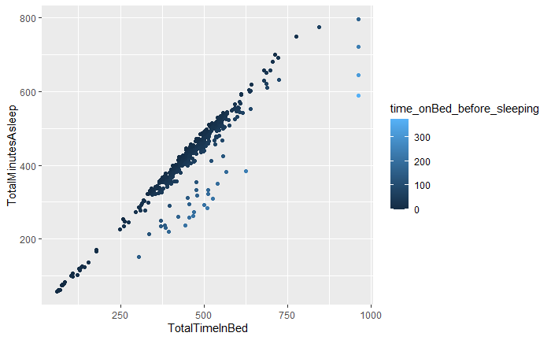

```r
ggplot(data = sleepDay)+
   geom_point(mapping = aes(x= TotalTimeInBed, y= TotalMinutesAsleep,
                            color=time_onBed_before_sleeping))
```

### Some discoveries :

#### the time before sleeping is high something, it looks like there is INSOMNIA with some participants .

#### I wonder if Bellabeat add instruction in Bellabeat`s App to guide the customers to avoid their INSOMNIA.

#### Explore the dailyIntensities :

```r
dailyIntensities <- dailyIntensities %>%
   select(Id, ActivityDay, SedentaryMinutes, LightlyActiveMinutes,
          FairlyActiveMinutes, VeryActiveMinutes)
```

#### more exploring :

```r
dailyIntensities %>%
   summary()
```

```
       Id            ActivityDay        SedentaryMinutes LightlyActiveMinutes
 Min.   :1.504e+09   Length:940         Min.   :   0.0   Min.   :  0.0
 1st Qu.:2.320e+09   Class :character   1st Qu.: 729.8   1st Qu.:127.0
 Median :4.445e+09   Mode  :character   Median :1057.5   Median :199.0
 Mean   :4.855e+09                      Mean   : 991.2   Mean   :192.8
 3rd Qu.:6.962e+09                      3rd Qu.:1229.5   3rd Qu.:264.0
 Max.   :8.878e+09                      Max.   :1440.0   Max.   :518.0
 FairlyActiveMinutes VeryActiveMinutes
 Min.   :  0.00      Min.   :  0.00
 1st Qu.:  0.00      1st Qu.:  0.00
 Median :  6.00      Median :  4.00
 Mean   : 13.56      Mean   : 21.16
 3rd Qu.: 19.00      3rd Qu.: 32.00
 Max.   :143.00      Max.   :210.00
```

#### dailyIntensities viz

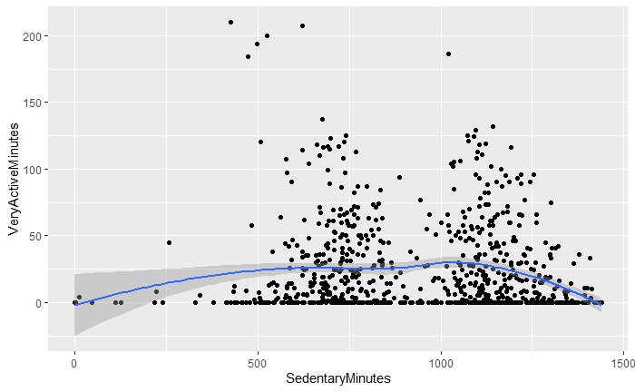

```r
ggplot(data = dailyIntensities)+
 geom_point(mapping = aes(x= SedentaryMinutes, y= VeryActiveMinutes )) +
   geom_smooth(mapping = aes(x= SedentaryMinutes, y= VeryActiveMinutes))
```

#### Discovery showed :

#### The Sedentary time is the most common between the participants.

#### Merge and explore Intensity combined with Sleep Day.

```r
intensity_sleepDay <- merge(dailyIntensities,sleepDay, by="Id", all = TRUE)
```

#### Explore the active time minutes :

```r
Stats_Very_Active_Minuts <- dailyIntensities %>%
summarise(min(VeryActiveMinutes),
          mean(VeryActiveMinutes),
          max(VeryActiveMinutes))
```

#### Some interesting discoveries :

#### the average and maximum of time on bed before sleeping are.

#### clearly greater than average and maximum of Very active minutes.

##### Thanks, and appreciated to interest on my first case study.

##### I am beginner and I know it is poor something case study.